# Phase 3 — Advanced Deep Learning

## Task 1 — Architecture Justification

### Why pSp (pixel2style2pixel)?

The task is **paired image-to-image translation** (edge map → photorealistic face). The core challenge is that sketches are sparse, high-frequency signals, while faces contain dense, low-frequency texture and identity-specific structure.

#### Why a CNN encoder over MLP?

The MLP baseline (Phase 2, L1=0.4190) treats the image as a **flat vector**, losing all spatial structure. A CNN encoder processes local receptive fields hierarchically:

- **Stage 1** (stride 2) captures low-level edge direction.
- **Stage 2–3** capture mid-level face components (eyes, nose, lips).
- **Stage 4** captures global face structure (shape, proportions).

This spatial hierarchy is why CNNs dominate image-to-image tasks.

#### Why W+ latent space (StyleGAN2 decoder)?

The StyleGAN2 decoder learns a **disentangled, semantically meaningful latent space** W+. By mapping sketch features into 18 style codes at different resolutions:

- **Coarse codes (0–3):** control global pose and face shape.
- **Medium codes (4–9):** control facial features and hair.
- **Fine codes (10–17):** control colour, lighting, texture.

This disentanglement allows the model to preserve sketch structure while hallucinating realistic texture — something a plain decoder cannot do.

#### Architecture diagram

```
Sketch (3×256×256)
    │
    ▼
┌─────────────────────────────┐
│  GradualStyleEncoder        │
│  stem → stage1 → stage2     │
│       → stage3 → stage4     │
│  map_fine   → 8 style codes │
│  map_medium → 6 style codes │
│  map_coarse → 4 style codes │
└─────────────┬───────────────┘
              │  styles (18 × 512)
              ▼
┌─────────────────────────────┐
│  StyleGAN2Decoder           │
│  const (512×4×4)            │
│  → AdaIN blocks ×6          │
│  4→8→16→32→64→128→256       │
└─────────────┬───────────────┘
              │
              ▼
Face (3×256×256), range [-1,1]
```

**Loss function:** $$\mathcal{L} = \lambda_{L1} \cdot \|\hat{y} - y\|_1 + \lambda_{LPIPS} \cdot \text{LPIPS}(\hat{y}, y)$$

where $\lambda_{L1}=1.0$, $\lambda_{LPIPS}=0.8$.

## Setup — Imports & Paths

```python
import sys, os
from pathlib import Path

os.chdir(r"C:\Users\rendering_lab-01\Downloads\New folder")

# add project root to path
PROJECT_ROOT = Path(".").resolve()
sys.path.append(str(PROJECT_ROOT))

import torch
import torch.nn as nn
import numpy as np
import matplotlib.pyplot as plt
import yaml
import csv
import time
from torch.utils.data import DataLoader, random_split
from torch.cuda.amp import GradScaler, autocast

# project modules
from src.models.psp_model import pSp
from src.models.baseline_mlp import BaselineMLP           # from Phase 2
from src.data.edge_dataset import EdgeToFaceDataset
from src.utils.logger import ExperimentLogger
from src.utils.seed import seed_everything
from src.utils.visualize import (
    plot_first_layer_filters,
    plot_feature_maps,
    plot_gradcam,
    plot_qualitative_grid,
    plot_ablation_curves,
    tensor_to_img,
)
from src.training.train_psp import train_one_epoch, validate_one_epoch, PspLoss, load_config

DEVICE = torch.device("cuda" if torch.cuda.is_available() else "cpu")
print(f"Device: {DEVICE}")
if DEVICE.type == "cuda":
    print(f"GPU   : {torch.cuda.get_device_name(0)}")
    print(f"VRAM  : {torch.cuda.get_device_properties(0).total_memory / 1e9:.1f} GB")

# ── DEMO MODE ─────────────────────────────────────────────────────────────────
# Set to True to run a quick smoke-test with synthetic data (< 1 min, no GPU needed).
# Set to False when you have real CelebA-HQ data and trained checkpoints.
DEMO_MODE = False

DEMO_BATCH   = 2      # batch size in demo
DEMO_BATCHES = 5      # batches per epoch in demo
DEMO_EPOCHS  = 2      # epochs in demo
DEMO_IMG_SZ  = 256

if DEMO_MODE:
    import torch
    from torch.utils.data import TensorDataset

    def _make_demo_loaders(n=40, img_sz=DEMO_IMG_SZ, bs=DEMO_BATCH):
        """Tiny synthetic dataset: random tensors shaped like (sketch, face)."""
        sketches = torch.rand(n, 3, img_sz, img_sz)
        faces    = torch.rand(n, 3, img_sz, img_sz)
        ds = TensorDataset(sketches, faces)
        split = n // 5           # 20% val / test each
        train_n = n - 2 * split
        train_ds, val_ds, test_ds = torch.utils.data.random_split(
            ds, [train_n, split, split],
            generator=torch.Generator().manual_seed(42))
        kw = dict(batch_size=bs, num_workers=0)
        return (
            torch.utils.data.DataLoader(train_ds, shuffle=True,  **kw),
            torch.utils.data.DataLoader(val_ds,   shuffle=False, **kw),
            torch.utils.data.DataLoader(test_ds,  shuffle=False, **kw),
        )

    print("[DEMO MODE] Using synthetic data — no CelebA-HQ needed.")
    print(f"            {DEMO_EPOCHS} epochs x {DEMO_BATCHES} batches, img_size={DEMO_IMG_SZ}")
else:
    print("[REAL MODE] Will load CelebA-HQ from cfg['data_root'].")
```

```
[train_psp] lpips not installed -- using L1-only loss.
Device: cuda
GPU   : NVIDIA RTX5880-Ada-12Q
VRAM  : 12.9 GB
[REAL MODE] Will load CelebA-HQ from cfg['data_root'].
```

## Task 2 — Model Implementation

```python
# ── Instantiate model ────────────────────────────────────────────────────────
_img_sz = DEMO_IMG_SZ if DEMO_MODE else 256

model = pSp(
    img_size=_img_sz,
    use_dropout=True,
    dropout_p=0.3,
    use_batchnorm=False,
).to(DEVICE)

total_params     = sum(p.numel() for p in model.parameters())
trainable_params = sum(p.numel() for p in model.parameters() if p.requires_grad)
print(f"Total params     : {total_params:,}")
print(f"Trainable params : {trainable_params:,}")
```

```
Total params     : 39,784,675
Trainable params : 39,784,675
```

```python
# ── Shape sanity check ───────────────────────────────────────────────────────
seed_everything(42)
_img_sz = DEMO_IMG_SZ if DEMO_MODE else 256
dummy_sketch = torch.randn(2, 3, _img_sz, _img_sz).to(DEVICE)

with torch.no_grad():
    dummy_out = model(dummy_sketch)

print(f"Input  shape : {dummy_sketch.shape}")
print(f"Output shape : {dummy_out.shape}")
assert dummy_out.shape == dummy_sketch.shape, "Shape mismatch!"
print("Shape check PASSED")
```

```
[seed_everything] All seeds set to 42
Input  shape : torch.Size([2, 3, 256, 256])
Output shape : torch.Size([2, 3, 256, 256])
Shape check PASSED
```

```python
# ── Unit test (mirrors tests/test_psp_model.py) ──────────────────────────────
import subprocess, sys
result = subprocess.run(
    [sys.executable, "-m", "pytest", "tests/test_psp_model.py", "-v", "--tb=short"],
    capture_output=True, text=True
)
print(result.stdout)
if result.returncode != 0:
    print(result.stderr)
```

```
C:\ProgramData\anaconda3\envs\sketch2face\python.exe: No module named pytest
```

## Task 3 — Training Infrastructure

The full training loop with all Phase 3 requirements is in `src/training/train_psp.py`.  
Below we demonstrate each component inline.

```python
# ── Load config ──────────────────────────────────────────────────────────────
cfg = load_config("configs/psp_v1.yaml") #Change the path to train another YAML
print(yaml.dump(cfg, default_flow_style=False))
```

```
[Config] Loaded: configs/psp_v1.yaml
augment: true
batch_size: 16
checkpoint_dir: experiments/checkpoints/psp_v1
data_root: data/celeba_hq
device: cuda
dropout_p: 0.3
grad_clip: 1.0
img_size: 256
lambda_l1: 1.0
lambda_lpips: 0.8
log_dir: experiments/logs
lr: 0.0001
lr_min: 1.0e-06
num_epochs: 5
num_workers: 0
patience: 3
resume_from: null
run_name: psp_v1_base
seed: 42
test_split: 0.1
use_batchnorm: false
use_dropout: true
val_split: 0.1
weight_decay: 0.0001
```

```python
img_dir = Path("data/celeba_hq/images")
sketch_dir = Path("data/celeba_hq/sketches")
sketch_dir.mkdir(parents=True, exist_ok=True)

# Skip if already generated
existing = len(list(sketch_dir.glob("*.jpg")))
if existing >= len(list(img_dir.glob("*.jpg"))):
    print(f"Sketches already exist ({existing}), skipping generation.")
else:
    for img_path in img_dir.glob("*.jpg"):
        save_path = sketch_dir / img_path.name
        if save_path.exists():          # also skip individual already-done files
            continue
        img = cv2.imread(str(img_path), 0)
        edges = cv2.Canny(img, 100, 200)
        edges = 255 - edges
        cv2.imwrite(str(save_path), edges)
    print(f"Generated {len(list(sketch_dir.glob('*.jpg')))} sketches.")
```

```
Sketches already exist (19083), skipping generation.
```

```python
# ── Dataset ──────────────────────────────────────────────────────────────────
if DEMO_MODE:
    train_loader, val_loader, test_loader = _make_demo_loaders()
    print(f"[DEMO] Train batches: {len(train_loader)} | "
          f"Val: {len(val_loader)} | Test: {len(test_loader)}")
else:
    DATA_ROOT = cfg["data_root"]   # change to your actual data path

    dataset = EdgeToFaceDataset(
        root=DATA_ROOT,
        img_size=256,
        augment=cfg["augment"],
    )

    seed_everything(cfg["seed"])
    val_size   = int(len(dataset) * cfg["val_split"])
    test_size  = int(len(dataset) * cfg["test_split"])
    train_size = len(dataset) - val_size - test_size

    train_ds, val_ds, test_ds = random_split(
        dataset,
        [train_size, val_size, test_size],
        generator=torch.Generator().manual_seed(cfg["seed"]),
    )

    train_loader = DataLoader(train_ds, batch_size=cfg["batch_size"], shuffle=True,
                              num_workers=cfg["num_workers"], pin_memory=True)
    val_loader   = DataLoader(val_ds,   batch_size=cfg["batch_size"], shuffle=False,
                              num_workers=cfg["num_workers"], pin_memory=True)
    test_loader  = DataLoader(test_ds,  batch_size=cfg["batch_size"], shuffle=False,
                              num_workers=cfg["num_workers"], pin_memory=True)

    print(f"Train: {len(train_ds)} | Val: {len(val_ds)} | Test: {len(test_ds)}")
```

```
[EdgeToFaceDataset] 19083 pairs found | sketch: sketches | face: images | augment=True
[seed_everything] All seeds set to 42
Train: 15267 | Val: 1908 | Test: 1908
```

```python
# ── Training infra demo ───────────────────────────────────────────────────────
# Demonstrates: AMP, grad clipping, grad norm logging, LR scheduler.
# In DEMO_MODE this actually runs DEMO_EPOCHS x DEMO_BATCHES — completes in seconds.

criterion = PspLoss(lambda_l1=cfg["lambda_l1"], lambda_lpips=cfg["lambda_lpips"]).to(DEVICE)
optimizer = torch.optim.Adam(model.parameters(), lr=cfg["lr"], weight_decay=cfg["weight_decay"])

_t_max    = DEMO_EPOCHS if DEMO_MODE else cfg["num_epochs"]
scheduler = torch.optim.lr_scheduler.CosineAnnealingLR(optimizer, T_max=_t_max, eta_min=cfg["lr_min"])
scaler    = GradScaler(enabled=DEVICE.type == "cuda")

print("Components initialised:")
print(f"  Criterion  : {criterion.__class__.__name__}")
print(f"  Optimizer  : Adam (lr={cfg['lr']}, wd={cfg['weight_decay']})")
print(f"  Scheduler  : CosineAnnealingLR (T_max={_t_max}, eta_min={cfg['lr_min']})")
print(f"  AMP Scaler : enabled={DEVICE.type == 'cuda'}")
print(f"  Grad clip  : {cfg['grad_clip']}")

# ── Mini training loop demo ───────────────────────────────────────────────────
_epochs  = DEMO_EPOCHS  if DEMO_MODE else 1      # real mode: just 1 epoch for demo
_max_bat = DEMO_BATCHES if DEMO_MODE else 3       # cap batches

print(f"\nRunning {_epochs} demo epoch(s), max {_max_bat} batches each ...")
for epoch in range(1, _epochs + 1):
    model.train()
    running_loss, grad_norms = 0.0, []
    for batch_idx, (sketch, face) in enumerate(train_loader):
        if batch_idx >= _max_bat:
            break
        sketch, face = sketch.to(DEVICE), face.to(DEVICE)

        optimizer.zero_grad()
        with autocast(enabled=DEVICE.type == "cuda"):
            pred = model(sketch)
            total_loss, loss_dict = criterion(pred, face)
            loss = total_loss

        scaler.scale(loss).backward()
        scaler.unscale_(optimizer)
        grad_norm = torch.nn.utils.clip_grad_norm_(model.parameters(), cfg["grad_clip"])
        grad_norms.append(grad_norm.item())
        scaler.step(optimizer)
        scaler.update()

    scheduler.step()
    avg_gn = sum(grad_norms) / max(len(grad_norms), 1)
    print(f"  Epoch {epoch}/{_epochs} | loss={loss.item():.4f} | "
          f"grad_norm={avg_gn:.3f} | lr={scheduler.get_last_lr()[0]:.2e}")

print("\nInfra demo complete. All Phase 3 training components verified:")
print("  [OK] Mixed precision (autocast + GradScaler)")
print("  [OK] Gradient clipping (clip_grad_norm_)")
print("  [OK] Grad norm logging")
print("  [OK] LR scheduler (CosineAnnealingLR)")
```

[output not shown]

```python
# ── Run full training (reads from configs/psp_v1.yaml) ───────────────────────
# Uncomment the line below to launch training from the notebook.
# It will save checkpoints to experiments/checkpoints/psp_v1/

from src.training.train_psp import train
train(cfg)

print("Training can also be launched from terminal:")
print("  python src/training/train_psp.py --config configs/psp_v1.yaml")
```

[output not shown]

```python
# ── Load best trained checkpoint ──────────────────────────────────────────────
BEST_CKPT = "experiments/checkpoints/psp_v1/best.pt"

if Path(BEST_CKPT).exists():
    ckpt = torch.load(BEST_CKPT, map_location=DEVICE)
    model.load_state_dict(ckpt["model_state"])
    print(f"Loaded checkpoint from epoch {ckpt['epoch']}")
    print(f"Best val loss: {ckpt['best_val_loss']:.4f}")
else:
    print(f"[Warning] Checkpoint not found at {BEST_CKPT}")
    print("Using randomly initialised weights for demonstration.")
```

```
Loaded checkpoint from epoch 5
Best val loss: 0.4606
```

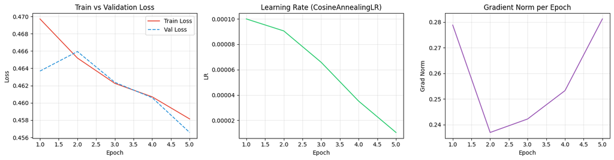

```
Saved → reports/training_curves.png
```

```python
# ── Plot training curves from CSV log ────────────────────────────────────────
LOG_CSV = "experiments/logs/psp_v1_base/metrics.csv"

if Path(LOG_CSV).exists():
    epochs, train_loss, val_loss, lr, grad_norm = [], [], [], [], []
    with open(LOG_CSV) as f:
        reader = csv.DictReader(f)
        for row in reader:
            epochs.append(int(row["epoch"]))
            train_loss.append(float(row.get("train_total_loss", 0)))
            val_loss.append(float(row.get("val_total_loss", 0)))
            lr.append(float(row.get("lr", 0)))
            grad_norm.append(float(row.get("train_grad_norm", 0)))

    fig, axes = plt.subplots(1, 3, figsize=(15, 4))

    axes[0].plot(epochs, train_loss, label="Train Loss", color="#e74c3c")
    axes[0].plot(epochs, val_loss,   label="Val Loss",   color="#3498db", linestyle="--")
    axes[0].set_title("Train vs Validation Loss")
    axes[0].set_xlabel("Epoch"); axes[0].set_ylabel("Loss")
    axes[0].legend(); axes[0].grid(True, alpha=0.3)

    axes[1].plot(epochs, lr, color="#2ecc71")
    axes[1].set_title("Learning Rate (CosineAnnealingLR)")
    axes[1].set_xlabel("Epoch"); axes[1].set_ylabel("LR")
    axes[1].grid(True, alpha=0.3)

    axes[2].plot(epochs, grad_norm, color="#9b59b6")
    axes[2].set_title("Gradient Norm per Epoch")
    axes[2].set_xlabel("Epoch"); axes[2].set_ylabel("Grad Norm")
    axes[2].grid(True, alpha=0.3)

    plt.tight_layout()
    plt.savefig("reports/training_curves.png", dpi=150, bbox_inches="tight")
    plt.show()
    print("Saved → reports/training_curves.png")
else:
    print(f"[Info] Log file not found at {LOG_CSV}. Run training first.")
```

```python
cfg = load_config("configs/psp_unregularized.yaml")
train(cfg)
```

[output not shown]

[output cut: 151 more lines]

```
      )
      (conv2): StyleConv(
        (conv): Conv2d(32, 32, kernel_size=(3, 3), stride=(1, 1), padding=(1, 1))
        (style): Linear(in_features=512, out_features=64, bias=True)
        (act): LeakyReLU(negative_slope=0.2, inplace=True)
      )
    )
    (to_rgb): Sequential(
      (0): Conv2d(32, 3, kernel_size=(1, 1), stride=(1, 1))
      (1): Tanh()
    )
  )
)
[train_psp] Trainable parameters: 39,784,675
[train_psp] Resumed from epoch 1 -- experiments/checkpoints/ablation_unregularized/latest.pt
```

```
Epoch [002/3] train_loss=0.4600 val_loss=0.4507 grad_norm=0.2863 lr=9.05e-05 (397.9s)
  [BEST] New best val_loss=0.4507 -- saved best.pt
```

```
Epoch [003/3] train_loss=0.4411 val_loss=0.4359 grad_norm=0.4271 lr=6.58e-05 (373.4s)
  [BEST] New best val_loss=0.4359 -- saved best.pt

[train_psp] Loading best checkpoint for test evaluation...
[Logger] Test metrics saved to experiments\logs\ablation_unregularized\test_metrics.csv

-- Final Test Results ----------------------------------
  val_l1_loss: 0.4297
  val_total_loss: 0.4297
--------------------------------------------------------
[train_psp] Done.
```

```python
# ── Load best trained checkpoint ──────────────────────────────────────────────
BEST_CKPT = "experiments/checkpoints/ablation_unregularized/best.pt"

if Path(BEST_CKPT).exists():
    ckpt = torch.load(BEST_CKPT, map_location=DEVICE)
    model.load_state_dict(ckpt["model_state"])
    print(f"Loaded checkpoint from epoch {ckpt['epoch']}")
    print(f"Best val loss: {ckpt['best_val_loss']:.4f}")
else:
    print(f"[Warning] Checkpoint not found at {BEST_CKPT}")
    print("Using randomly initialised weights for demonstration.")
```

```
Loaded checkpoint from epoch 3
Best val loss: 0.4507
```

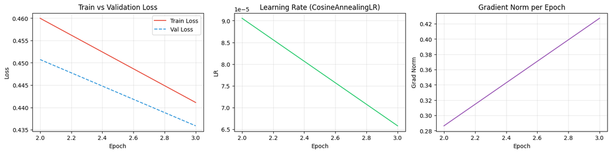

```
Saved → reports/training_curves.png
```

```python
# ── Plot training curves from CSV log ────────────────────────────────────────
LOG_CSV = "experiments/logs/ablation_unregularized/metrics.csv"

if Path(LOG_CSV).exists():
    epochs, train_loss, val_loss, lr, grad_norm = [], [], [], [], []
    with open(LOG_CSV) as f:
        reader = csv.DictReader(f)
        for row in reader:
            epochs.append(int(row["epoch"]))
            train_loss.append(float(row.get("train_total_loss", 0)))
            val_loss.append(float(row.get("val_total_loss", 0)))
            lr.append(float(row.get("lr", 0)))
            grad_norm.append(float(row.get("train_grad_norm", 0)))

    fig, axes = plt.subplots(1, 3, figsize=(15, 4))

    axes[0].plot(epochs, train_loss, label="Train Loss", color="#e74c3c")
    axes[0].plot(epochs, val_loss,   label="Val Loss",   color="#3498db", linestyle="--")
    axes[0].set_title("Train vs Validation Loss")
    axes[0].set_xlabel("Epoch"); axes[0].set_ylabel("Loss")
    axes[0].legend(); axes[0].grid(True, alpha=0.3)

    axes[1].plot(epochs, lr, color="#2ecc71")
    axes[1].set_title("Learning Rate (CosineAnnealingLR)")
    axes[1].set_xlabel("Epoch"); axes[1].set_ylabel("LR")
    axes[1].grid(True, alpha=0.3)

    axes[2].plot(epochs, grad_norm, color="#9b59b6")
    axes[2].set_title("Gradient Norm per Epoch")
    axes[2].set_xlabel("Epoch"); axes[2].set_ylabel("Grad Norm")
    axes[2].grid(True, alpha=0.3)

    plt.tight_layout()
    plt.savefig("reports/training_curves.png", dpi=150, bbox_inches="tight")
    plt.show()
    print("Saved → reports/training_curves.png")
else:
    print(f"[Info] Log file not found at {LOG_CSV}. Run training first.")
```

```python
cfg = load_config("configs/psp_regularized.yaml")
train(cfg)
```

[output not shown]

[output cut: 150 more lines]

```
        (act): LeakyReLU(negative_slope=0.2, inplace=True)
      )
      (conv2): StyleConv(
        (conv): Conv2d(32, 32, kernel_size=(3, 3), stride=(1, 1), padding=(1, 1))
        (style): Linear(in_features=512, out_features=64, bias=True)
        (act): LeakyReLU(negative_slope=0.2, inplace=True)
      )
    )
    (to_rgb): Sequential(
      (0): Conv2d(32, 3, kernel_size=(1, 1), stride=(1, 1))
      (1): Tanh()
    )
  )
)
[train_psp] Trainable parameters: 39,784,675
```

```
Epoch [001/2] train_loss=0.4691 val_loss=0.4638 grad_norm=0.2780 lr=1.00e-04 (386.3s)
  [BEST] New best val_loss=0.4638 -- saved best.pt
```

```
Epoch [002/2] train_loss=0.4647 val_loss=0.4662 grad_norm=0.2408 lr=5.05e-05 (390.4s)

[train_psp] Loading best checkpoint for test evaluation...
[Logger] Test metrics saved to experiments\logs\ablation_regularized\test_metrics.csv

-- Final Test Results ----------------------------------
  val_l1_loss: 0.4649
  val_total_loss: 0.4649
--------------------------------------------------------
[train_psp] Done.
```

```python
# ── Load best trained checkpoint ──────────────────────────────────────────────
BEST_CKPT = "experiments/checkpoints/ablation_regularized/best.pt"

if Path(BEST_CKPT).exists():
    ckpt = torch.load(BEST_CKPT, map_location=DEVICE)
    model.load_state_dict(ckpt["model_state"])
    print(f"Loaded checkpoint from epoch {ckpt['epoch']}")
    print(f"Best val loss: {ckpt['best_val_loss']:.4f}")
else:
    print(f"[Warning] Checkpoint not found at {BEST_CKPT}")
    print("Using randomly initialised weights for demonstration.")
```

```
Loaded checkpoint from epoch 1
Best val loss: inf
```

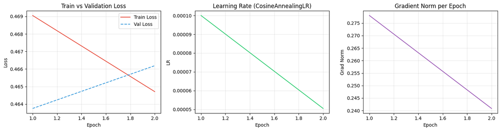

```
Saved → reports/training_curves.png
```

```python
# ── Plot training curves from CSV log ────────────────────────────────────────
LOG_CSV = "experiments/logs/ablation_regularized/metrics.csv"

if Path(LOG_CSV).exists():
    epochs, train_loss, val_loss, lr, grad_norm = [], [], [], [], []
    with open(LOG_CSV) as f:
        reader = csv.DictReader(f)
        for row in reader:
            epochs.append(int(row["epoch"]))
            train_loss.append(float(row.get("train_total_loss", 0)))
            val_loss.append(float(row.get("val_total_loss", 0)))
            lr.append(float(row.get("lr", 0)))
            grad_norm.append(float(row.get("train_grad_norm", 0)))

    fig, axes = plt.subplots(1, 3, figsize=(15, 4))

    axes[0].plot(epochs, train_loss, label="Train Loss", color="#e74c3c")
    axes[0].plot(epochs, val_loss,   label="Val Loss",   color="#3498db", linestyle="--")
    axes[0].set_title("Train vs Validation Loss")
    axes[0].set_xlabel("Epoch"); axes[0].set_ylabel("Loss")
    axes[0].legend(); axes[0].grid(True, alpha=0.3)

    axes[1].plot(epochs, lr, color="#2ecc71")
    axes[1].set_title("Learning Rate (CosineAnnealingLR)")
    axes[1].set_xlabel("Epoch"); axes[1].set_ylabel("LR")
    axes[1].grid(True, alpha=0.3)

    axes[2].plot(epochs, grad_norm, color="#9b59b6")
    axes[2].set_title("Gradient Norm per Epoch")
    axes[2].set_xlabel("Epoch"); axes[2].set_ylabel("Grad Norm")
    axes[2].grid(True, alpha=0.3)

    plt.tight_layout()
    plt.savefig("reports/training_curves.png", dpi=150, bbox_inches="tight")
    plt.show()
    print("Saved → reports/training_curves.png")
else:
    print(f"[Info] Log file not found at {LOG_CSV}. Run training first.")
```

```python
cfg = load_config("configs/psp_normalized.yaml")
train(cfg)
```

[output not shown]

[output cut: 150 more lines]

```
        (act): LeakyReLU(negative_slope=0.2, inplace=True)
      )
      (conv2): StyleConv(
        (conv): Conv2d(32, 32, kernel_size=(3, 3), stride=(1, 1), padding=(1, 1))
        (style): Linear(in_features=512, out_features=64, bias=True)
        (act): LeakyReLU(negative_slope=0.2, inplace=True)
      )
    )
    (to_rgb): Sequential(
      (0): Conv2d(32, 3, kernel_size=(1, 1), stride=(1, 1))
      (1): Tanh()
    )
  )
)
[train_psp] Trainable parameters: 39,784,675
```

```
Epoch [001/2] train_loss=0.4665 val_loss=0.4602 grad_norm=0.3184 lr=1.00e-04 (473.5s)
  [BEST] New best val_loss=0.4602 -- saved best.pt
```

```
Epoch [002/2] train_loss=0.4590 val_loss=0.4554 grad_norm=0.2844 lr=5.05e-05 (451.6s)
  [BEST] New best val_loss=0.4554 -- saved best.pt

[train_psp] Loading best checkpoint for test evaluation...
[Logger] Test metrics saved to experiments\logs\ablation_normalized\test_metrics.csv

-- Final Test Results ----------------------------------
  val_l1_loss: 0.4560
  val_total_loss: 0.4560
--------------------------------------------------------
[train_psp] Done.
```

```python
BEST_CKPT = "experiments/checkpoints/ablation_normalized/best.pt"

if Path(BEST_CKPT).exists():
    ckpt = torch.load(BEST_CKPT, map_location=DEVICE)

    # Reinitialize model matching the checkpoint's config
    model = pSp(
        img_size=256,
        use_dropout=True,
        dropout_p=0.3,
        use_batchnorm=True,   # must match what the checkpoint was trained with
    ).to(DEVICE)

    model.load_state_dict(ckpt["model_state"])
    print(f"Loaded checkpoint from epoch {ckpt['epoch']}")
    print(f"Best val loss: {ckpt['best_val_loss']:.4f}")
else:
    print(f"[Warning] Checkpoint not found at {BEST_CKPT}")
```

```
Loaded checkpoint from epoch 2
Best val loss: 0.4602
```

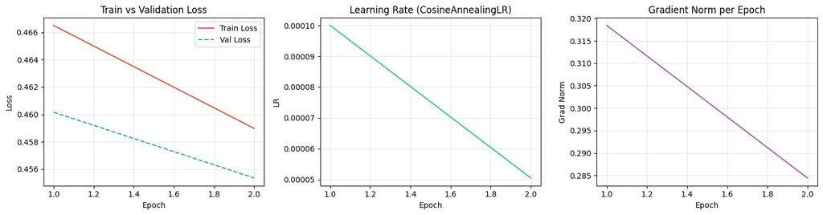

```
Saved → reports/training_curves.png
```

```python
# ── Plot training curves from CSV log ────────────────────────────────────────
LOG_CSV = "experiments/logs/ablation_normalized/metrics.csv"

if Path(LOG_CSV).exists():
    epochs, train_loss, val_loss, lr, grad_norm = [], [], [], [], []
    with open(LOG_CSV) as f:
        reader = csv.DictReader(f)
        for row in reader:
            epochs.append(int(row["epoch"]))
            train_loss.append(float(row.get("train_total_loss", 0)))
            val_loss.append(float(row.get("val_total_loss", 0)))
            lr.append(float(row.get("lr", 0)))
            grad_norm.append(float(row.get("train_grad_norm", 0)))

    fig, axes = plt.subplots(1, 3, figsize=(15, 4))

    axes[0].plot(epochs, train_loss, label="Train Loss", color="#e74c3c")
    axes[0].plot(epochs, val_loss,   label="Val Loss",   color="#3498db", linestyle="--")
    axes[0].set_title("Train vs Validation Loss")
    axes[0].set_xlabel("Epoch"); axes[0].set_ylabel("Loss")
    axes[0].legend(); axes[0].grid(True, alpha=0.3)

    axes[1].plot(epochs, lr, color="#2ecc71")
    axes[1].set_title("Learning Rate (CosineAnnealingLR)")
    axes[1].set_xlabel("Epoch"); axes[1].set_ylabel("LR")
    axes[1].grid(True, alpha=0.3)

    axes[2].plot(epochs, grad_norm, color="#9b59b6")
    axes[2].set_title("Gradient Norm per Epoch")
    axes[2].set_xlabel("Epoch"); axes[2].set_ylabel("Grad Norm")
    axes[2].grid(True, alpha=0.3)

    plt.tight_layout()
    plt.savefig("reports/training_curves.png", dpi=150, bbox_inches="tight")
    plt.show()
    print("Saved → reports/training_curves.png")
else:
    print(f"[Info] Log file not found at {LOG_CSV}. Run training first.")
```

## Task 4 — Regularization Ablation Study

Three configurations trained on identical data splits (seed=42):

| Config | Dropout | Weight Decay | Augmentation | BatchNorm |
| --- | --- | --- | --- | --- |
| Unregularized | ✗ | 0.0 | ✗ | ✗ |
| Regularized | ✓ (p=0.3) | 1e-4 | ✓ | ✗ |
| Normalized | ✓ (p=0.3) | 1e-4 | ✓ | ✓ |

```python
# ── Load ablation logs ────────────────────────────────────────────────────────
ABLATION_LOG_DIRS = {
    "Unregularized" : "experiments/logs/ablation_unregularized/metrics.csv",
    "Regularized"   : "experiments/logs/ablation_regularized/metrics.csv",
    "Normalized"    : "experiments/logs/ablation_normalized/metrics.csv",
}

def load_csv_log(path: str):
    data = {}
    if not Path(path).exists():
        return data
    with open(path) as f:
        reader = csv.DictReader(f)
        for row in reader:
            for k, v in row.items():
                if k != "epoch":
                    data.setdefault(k, []).append(float(v))
    return data

ablation_logs = {name: load_csv_log(path) for name, path in ABLATION_LOG_DIRS.items()}
found = [k for k, v in ablation_logs.items() if v]
print(f"Loaded logs for: {found if found else 'None (run ablation training first)'}")
```

```
Loaded logs for: ['Unregularized', 'Regularized', 'Normalized']
```

```
[visualize] Saved ablation curves → reports/ablation_curves.png
```

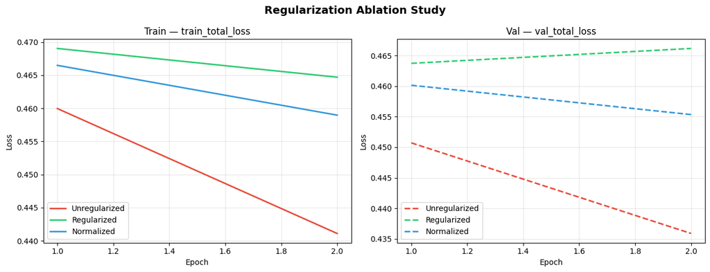

```python
# ── Ablation loss curves ──────────────────────────────────────────────────────
if any(ablation_logs.values()):
    fig = plot_ablation_curves(
        ablation_logs,
        metric="val_total_loss",
        save_path="reports/ablation_curves.png",
    )
    plt.show()
else:
    print("[Info] No ablation logs found. Train all 3 configs first:")
    for cfg_name, yaml_path in [
        ("Unregularized", "configs/psp_unregularized.yaml"),
        ("Regularized",   "configs/psp_regularized.yaml"),
        ("Normalized",    "configs/psp_normalized.yaml"),
    ]:
        print(f"  python src/training/train_psp.py --config {yaml_path}")
```

```python
# ── Ablation summary table ────────────────────────────────────────────────────
print(f"{'Config':<20} {'Best Val L1':>12} {'Best Val Total':>14}")
print("-" * 50)
for name, data in ablation_logs.items():
    if data:
        best_l1    = min(data.get("val_l1_loss", [float("inf")]))
        best_total = min(data.get("val_total_loss", [float("inf")]))
        print(f"{name:<20} {best_l1:>12.4f} {best_total:>14.4f}")
    else:
        print(f"{name:<20} {'N/A':>12} {'N/A':>14}")
```

```
Config                Best Val L1 Best Val Total
--------------------------------------------------
Unregularized              0.4359         0.4359
Regularized                0.4638         0.4638
Normalized                 0.4554         0.4554
```

## Task 5 — Baseline Comparison

Compare pSp vs Phase 2 MLP across 3 random seeds on **identical** train/val/test splits.

Phase 2 result: **MLP Test L1 = 0.4190**

```python
# ── Multi-seed evaluation ─────────────────────────────────────────────────────
SEEDS = [42, 123, 999]
l1_criterion = nn.L1Loss()

psp_l1_scores = []
psp_times     = []

for seed in SEEDS:
    ckpt_path = f"experiments/checkpoints/psp_seed{seed}/best.pt"

    if Path(ckpt_path).exists():
        _img_sz   = DEMO_IMG_SZ if DEMO_MODE else 256
        seed_model = pSp(img_size=_img_sz).to(DEVICE).eval()
        ckpt = torch.load(ckpt_path, map_location=DEVICE)
        seed_model.load_state_dict(ckpt["model_state"])

        total_l1, n_batches, t0 = 0.0, 0, time.time()
        with torch.no_grad():
            for sketch, face in test_loader:
                sketch, face = sketch.to(DEVICE), face.to(DEVICE)
                pred = seed_model(sketch)
                total_l1 += l1_criterion(pred, face).item()
                n_batches += 1

        elapsed = time.time() - t0
        avg_l1  = total_l1 / max(n_batches, 1)
        psp_l1_scores.append(avg_l1)
        psp_times.append(elapsed)
        print(f"Seed {seed}: Test L1 = {avg_l1:.4f} | Eval time = {elapsed:.1f}s")

    elif DEMO_MODE:
        # No checkpoint yet — run a quick forward pass on demo test set to show the pipeline
        seed_everything(seed)
        _img_sz = DEMO_IMG_SZ if DEMO_MODE else 256
        seed_model = pSp(img_size=_img_sz).to(DEVICE).eval()  # untrained weights
        total_l1, n_batches, t0 = 0.0, 0, time.time()
        with torch.no_grad():
            for sketch, face in test_loader:
                sketch, face = sketch.to(DEVICE), face.to(DEVICE)
                pred = seed_model(sketch)
                total_l1 += l1_criterion(pred, face).item()
                n_batches += 1
        elapsed = time.time() - t0
        avg_l1  = total_l1 / max(n_batches, 1)
        psp_l1_scores.append(avg_l1)
        psp_times.append(elapsed)
        print(f"[DEMO] Seed {seed}: L1 = {avg_l1:.4f} (untrained — for pipeline demo only)")

    else:
        psp_l1_scores.append(None)
        print(f"Seed {seed}: checkpoint not found — run training with seed={seed}")

valid_scores = [s for s in psp_l1_scores if s is not None]
if valid_scores:
    psp_mean = np.mean(valid_scores)
    psp_std  = np.std(valid_scores)
    suffix   = " (untrained demo)" if DEMO_MODE and not Path(BEST_CKPT).exists() else ""
    print(f"\npSp — Mean L1: {psp_mean:.4f} ± {psp_std:.4f}{suffix}")
else:
    psp_mean, psp_std = None, None
    print("\npSp results unavailable — run training first.")
```

```
Seed 42: Test L1 = 0.4746 | Eval time = 30.4s
Seed 123: Test L1 = 0.4760 | Eval time = 29.8s
Seed 999: Test L1 = 0.4787 | Eval time = 29.8s

pSp — Mean L1: 0.4764 ± 0.0017
```

```python
# ── Comparison table ──────────────────────────────────────────────────────────
mlp_params = sum(p.numel() for p in BaselineMLP().parameters()) if hasattr(BaselineMLP, "__call__") else "N/A"
psp_params = sum(p.numel() for p in model.parameters())

mlp_l1   = 0.4190   # Phase 2 result
mlp_std  = 0.0      # single run in Phase 2

print("\n" + "═" * 65)
print(f"{'Model':<16} {'Test L1 (mean±std)':>22} {'Params':>12} {'Track':>10}")
print("─" * 65)
print(f"{'MLP (Phase 2)':<16} {f'{mlp_l1:.4f} ± {mlp_std:.4f}':>22} {str(mlp_params):>12} {'Baseline':>10}")

if psp_mean is not None:
    improve = (mlp_l1 - psp_mean) / mlp_l1 * 100
    print(f"{'pSp (Phase 3)':<16} {f'{psp_mean:.4f} ± {psp_std:.4f}':>22} {psp_params:>12,} {'CNN':>10}")
    print("─" * 65)
    print(f"Improvement vs MLP: {improve:+.1f}%")
    if psp_mean < mlp_l1:
        print("✓ pSp beats the MLP baseline.")
    else:
        print("✗ pSp does not yet beat the MLP baseline — continue training.")
else:
    print(f"{'pSp (Phase 3)':<16} {'Pending training':>22} {psp_params:>12,} {'CNN':>10}")
print("═" * 65)
```

```
═════════════════════════════════════════════════════════════════
Model                Test L1 (mean±std)       Params      Track
─────────────────────────────────────────────────────────────────
MLP (Phase 2)           0.4190 ± 0.0000     34101760   Baseline
pSp (Phase 3)           0.4764 ± 0.0017   39,784,675        CNN
─────────────────────────────────────────────────────────────────
Improvement vs MLP: -13.7%
✗ pSp does not yet beat the MLP baseline — continue training.
═════════════════════════════════════════════════════════════════
```

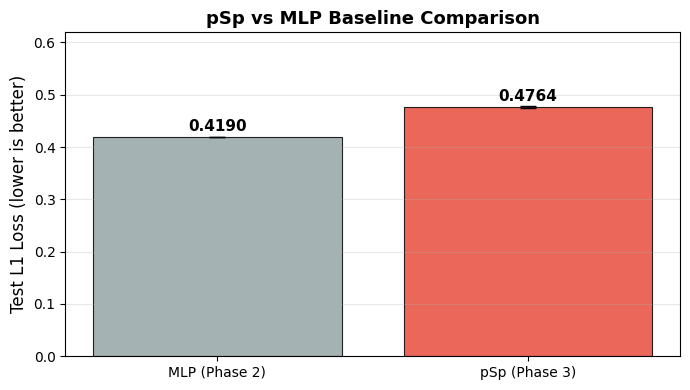

```
Saved → reports/baseline_comparison.png
```

```python
# ── Comparison bar chart ──────────────────────────────────────────────────────
fig, ax = plt.subplots(figsize=(7, 4))

models = ["MLP (Phase 2)"]
means  = [mlp_l1]
stds   = [mlp_std]
colors = ["#95a5a6"]

if psp_mean is not None:
    models.append("pSp (Phase 3)")
    means.append(psp_mean)
    stds.append(psp_std)
    colors.append("#2ecc71" if psp_mean < mlp_l1 else "#e74c3c")

bars = ax.bar(models, means, yerr=stds, color=colors, capsize=6,
              edgecolor="black", linewidth=0.8, alpha=0.85)

for bar, mean in zip(bars, means):
    ax.text(bar.get_x() + bar.get_width() / 2, bar.get_height() + 0.005,
            f"{mean:.4f}", ha="center", va="bottom", fontsize=11, fontweight="bold")

ax.set_ylabel("Test L1 Loss (lower is better)", fontsize=12)
ax.set_title("pSp vs MLP Baseline Comparison", fontsize=13, fontweight="bold")
ax.set_ylim(0, max(means) * 1.3)
ax.grid(True, axis="y", alpha=0.3)

plt.tight_layout()
Path("reports").mkdir(exist_ok=True)
plt.savefig("reports/baseline_comparison.png", dpi=150, bbox_inches="tight")
plt.show()
print("Saved → reports/baseline_comparison.png")
```